# Lab2

Álvaro Ribot

24/02/2020

# Exercici 1

## a)

### Carregueu les dades dins l’entorn de R amb la instrucci ́o read.table. Cal- culeu l’edat (Age) dels atletes en anys amb Age = 2019 - Year of birth. Cal crear una nova matriu (o dataframe) contenint nomes les 10 variables a continuaci ́o que utilitzarem per un an`alisi de components principals: Age, Speed, Dist, DP, A, B, C, D, E i JP. Conv ́e etiquetar les files de la nova matriu amb els noms dels atletes, i etiquetar les columnes de la matriu amb els noms de les variables. La variable Total es guarda per separat i no s’utilitza com a variable d’entrada en el ACP. Quantes observacions cont ́e la base de dades? Feu boxplots de les variables amb la instrucci ́o boxplot. Feu una matriu de diagrames bivariants (scatterplot matrix) de les variables seleccionades. Comenteu els vostres resul- tats. Calculeu la matriu de correlacions.

```r
library(car)
```

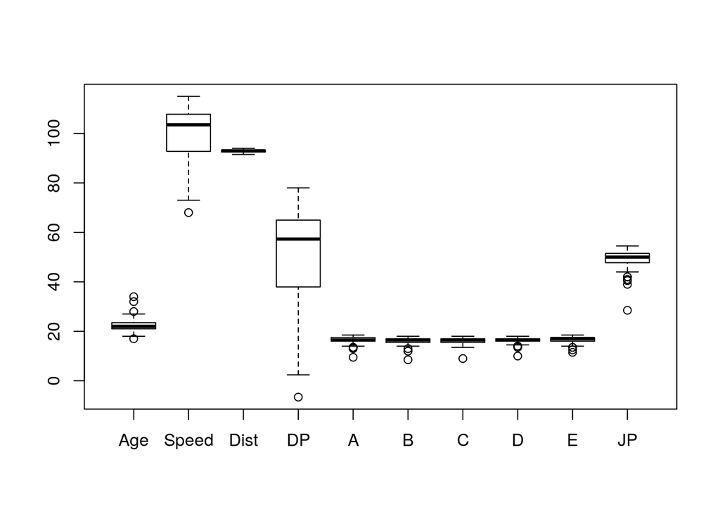

```r
X <- read.table("http://www-eio.upc.es/~jan/Data/MVA/Einsiedeln.dat", header = T)
X$Age <- 2019 - X$Year
dd <- X[,c("Age", "Speed", "Dist", "DP", "A", "B", "C", "D", "E", "JP")]
rownames(dd) <- paste(X$Name, X$Surname, sep = " ")
Total <- X$Total
boxplot(dd)
```

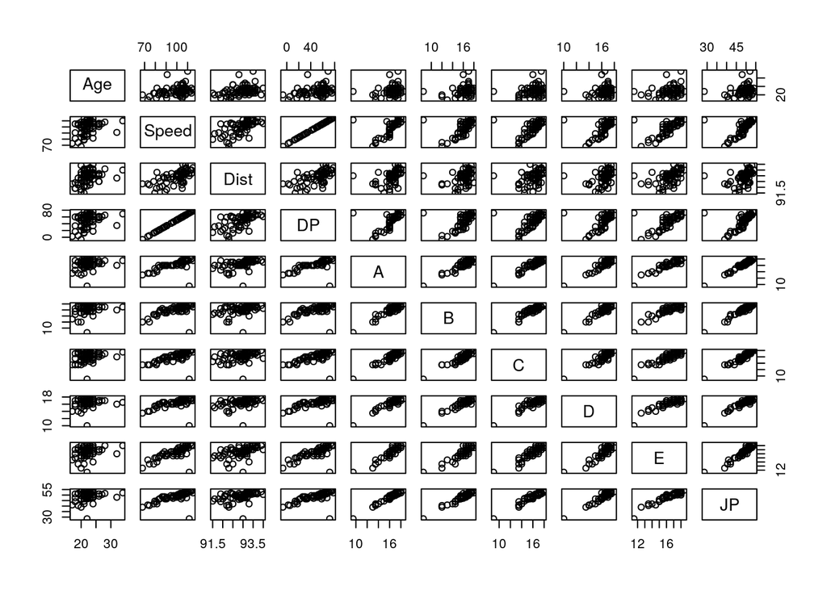

```r
pairs(dd)
```

```r
cor(dd)
```

```
##             Age     Speed      Dist        DP         A         B
## Age   1.0000000 0.3438716 0.3677421 0.3438716 0.2401831 0.2571517
## Speed 0.3438716 1.0000000 0.6401114 1.0000000 0.6472835 0.5889190
## Dist  0.3677421 0.6401114 1.0000000 0.6401114 0.4431201 0.3729518
## DP    0.3438716 1.0000000 0.6401114 1.0000000 0.6472835 0.5889190
## A     0.2401831 0.6472835 0.4431201 0.6472835 1.0000000 0.9275251
## B     0.2571517 0.5889190 0.3729518 0.5889190 0.9275251 1.0000000
## C     0.2380597 0.6257800 0.4054893 0.6257800 0.9344801 0.9303601
## D     0.2026335 0.5409701 0.3623323 0.5409701 0.9300906 0.9277636
## E     0.2902089 0.7369053 0.5081254 0.7369053 0.9362690 0.9059886
## JP    0.2446224 0.6402096 0.4269148 0.6402096 0.9803432 0.9700749
##               C         D         E        JP
## Age   0.2380597 0.2026335 0.2902089 0.2446224
## Speed 0.6257800 0.5409701 0.7369053 0.6402096
## Dist  0.4054893 0.3623323 0.5081254 0.4269148
## DP    0.6257800 0.5409701 0.7369053 0.6402096
## A     0.9344801 0.9300906 0.9362690 0.9803432
## B     0.9303601 0.9277636 0.9059886 0.9700749
## C     1.0000000 0.8969266 0.9039050 0.9635600
## D     0.8969266 1.0000000 0.8858514 0.9558192
## E     0.9039050 0.8858514 1.0000000 0.9514295
## JP    0.9635600 0.9558192 0.9514295 1.0000000
```

## b)

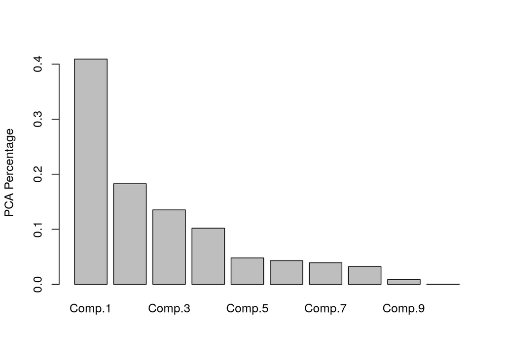

```r
pca <- princomp(dd, cor =T)
pca_perc <- pca$sdev/sum(pca$sdev)
pca_cum <- cumsum(pca_perc)
barplot(pca_perc, ylab = "PCA Percentage")
```

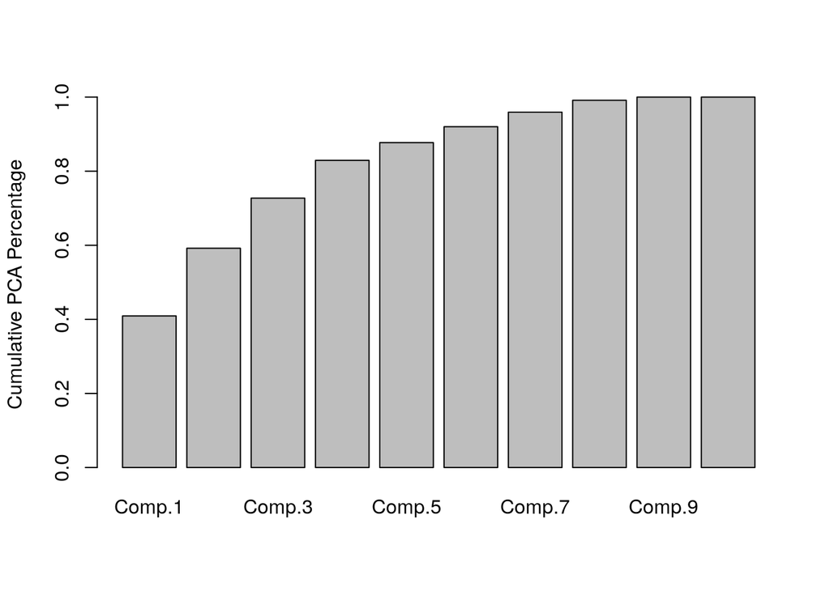

```r
barplot(pca_cum, ylab = "Cumulative PCA Percentage")
```

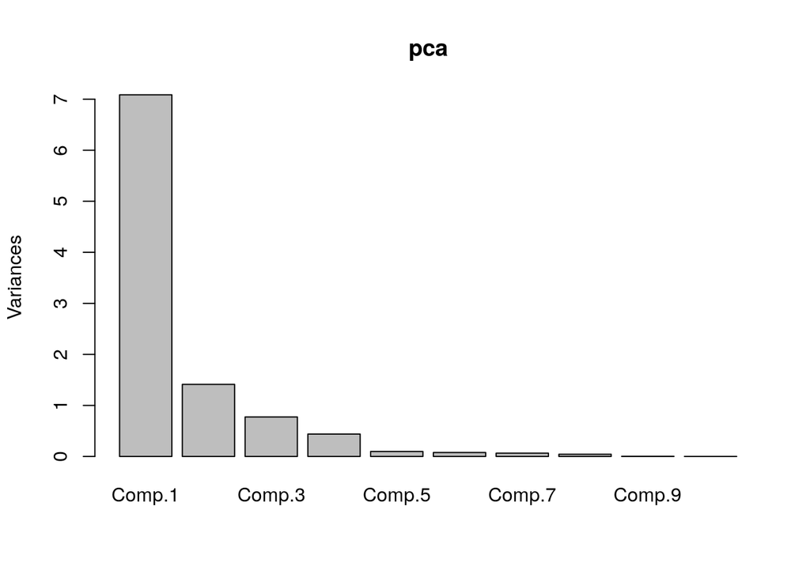

```r
screeplot(pca)
```

```r
summary(pca)
```

```
## Importance of components:
##                          Comp.1    Comp.2     Comp.3     Comp.4
## Standard deviation     2.661992 1.1886259 0.87992491 0.66287696
## Proportion of Variance 0.708620 0.1412832 0.07742678 0.04394059
## Cumulative Proportion  0.708620 0.8499031 0.92732993 0.97127052
##                             Comp.5     Comp.6     Comp.7      Comp.8
## Standard deviation     0.312199900 0.27900950 0.25513310 0.209167655
## Proportion of Variance 0.009746878 0.00778463 0.00650929 0.004375111
## Cumulative Proportion  0.981017398 0.98880203 0.99531132 0.999686429
##                              Comp.9 Comp.10
## Standard deviation     0.0559974316       0
## Proportion of Variance 0.0003135712       0
## Cumulative Proportion  1.0000000000       1
```

## c)

The last principal component variance is zero because there are two linearly dependent variables i.e. their correlation is $1$ (Speed and DP).

## d)

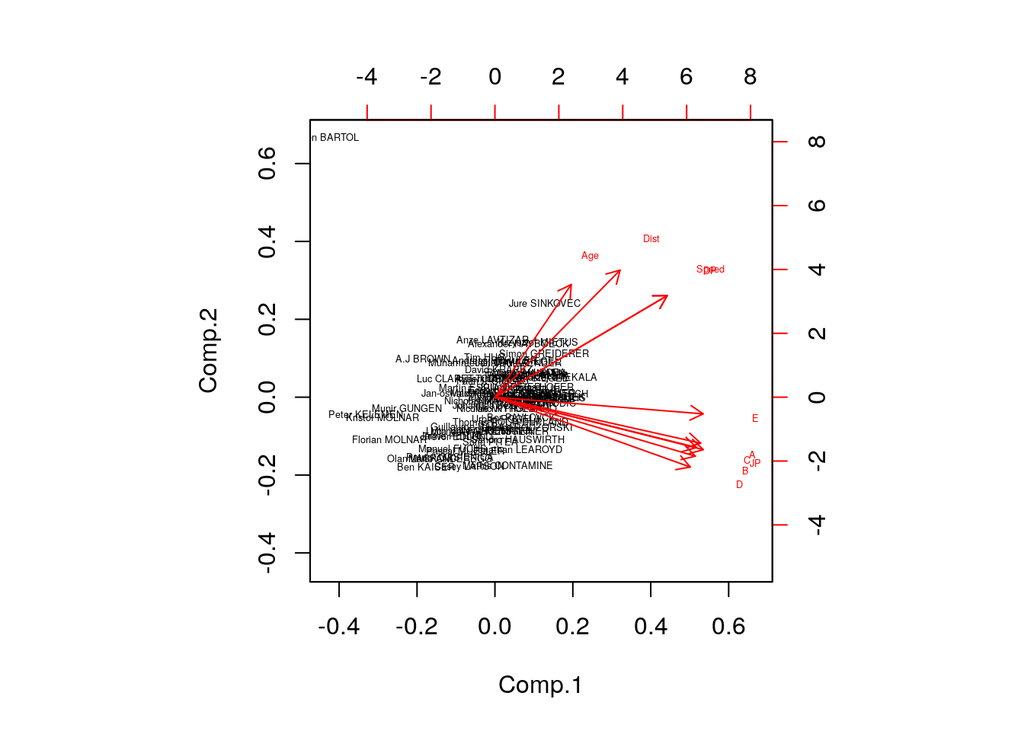

```r
biplot(pca, cex =0.4)
```

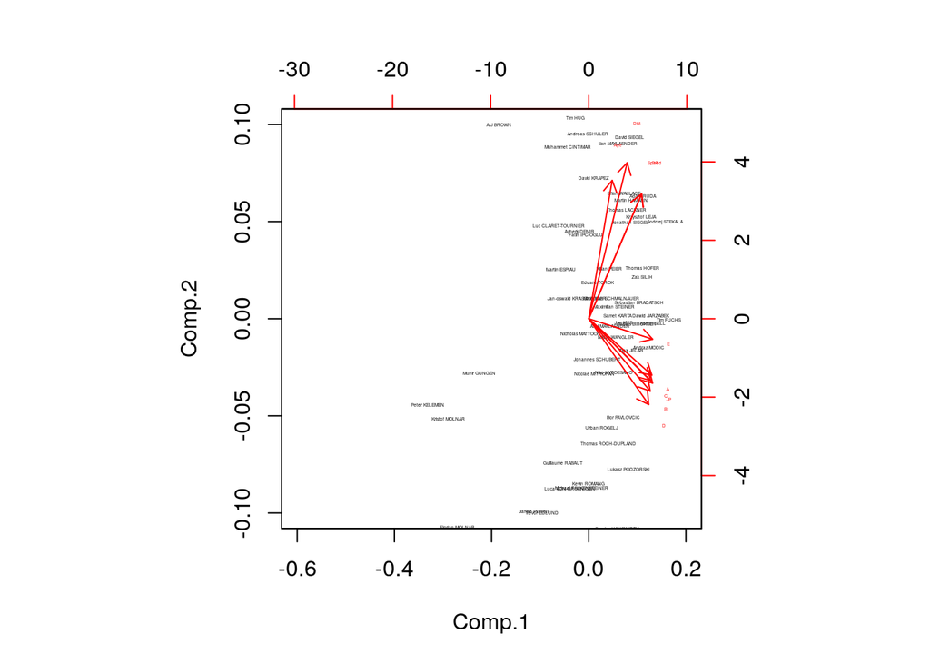

```r
biplot(pca, xlim = c(-0.6, 0.2), ylim = c(-0.1, 0.1), cex = 0.2)
```

Tilen BARTOL is a possible anomaly. Looking at the boxplots we note that Tilen BARTOL is an outlier in variables A, B, C, D, E and JP. This means that he has very low scores.

```r
dd["Tilen BARTOL",]
```

```
##              Age Speed Dist   DP   A   B C  D    E   JP
## Tilen BARTOL  22 111.5   93 71.7 9.5 8.5 9 10 11.5 28.5
```

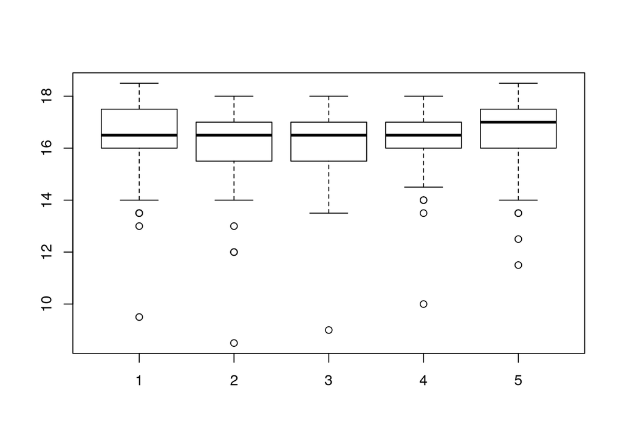

```r
boxplot(dd$A, dd$B, dd$C, dd$D, dd$E)
```

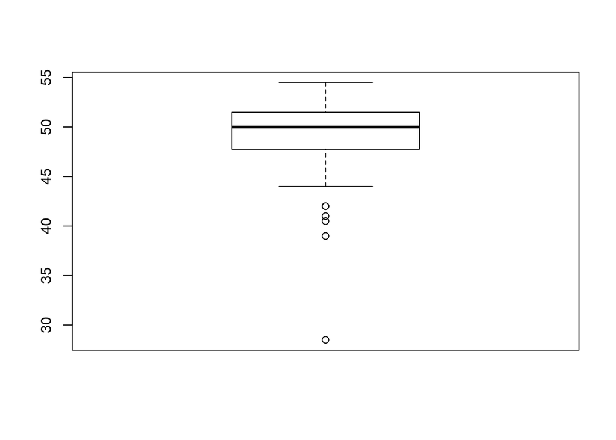

```r
boxplot(dd$JP)
```

## e)

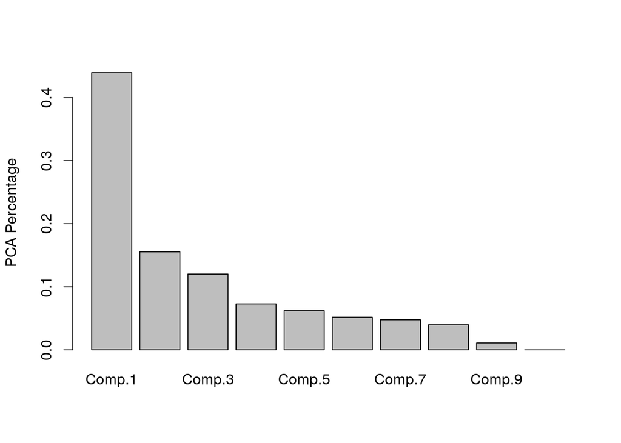

```r
dd2 <- dd[rownames(dd) != c("Tilen BARTOL"),]
pca2 <- princomp(dd2, cor =T)
pca2_perc <- pca2$sdev/sum(pca2$sdev)
pca2_cum <- cumsum(pca2_perc)
barplot(pca2_perc, ylab = "PCA Percentage")
```

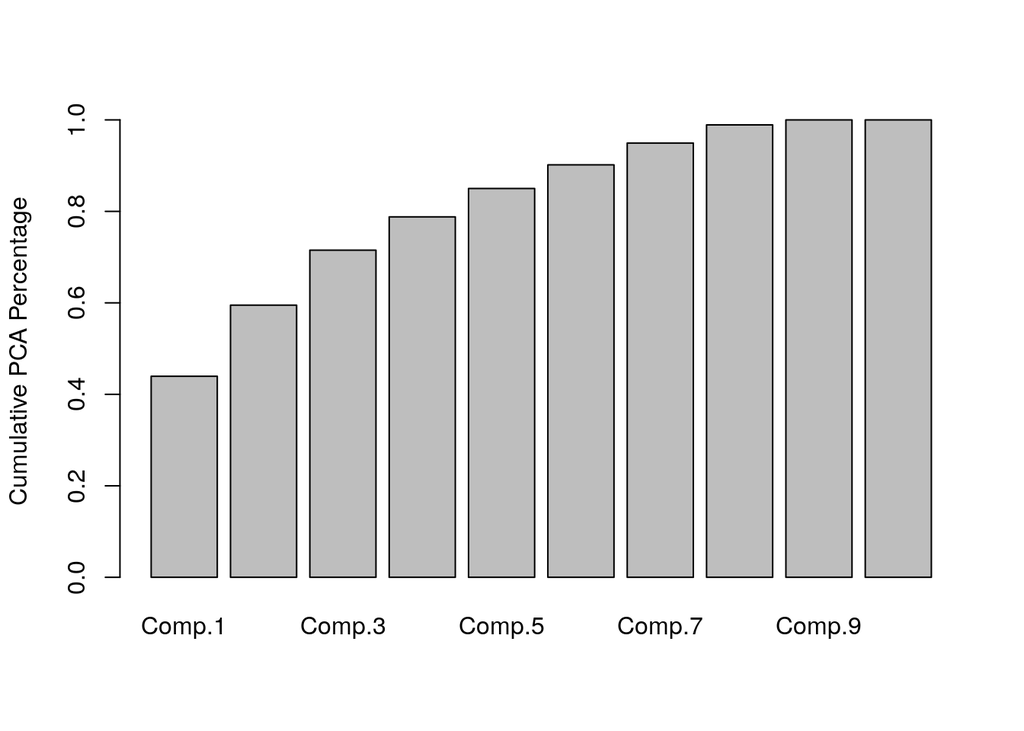

```r
barplot(pca2_cum, ylab = "Cumulative PCA Percentage")
```

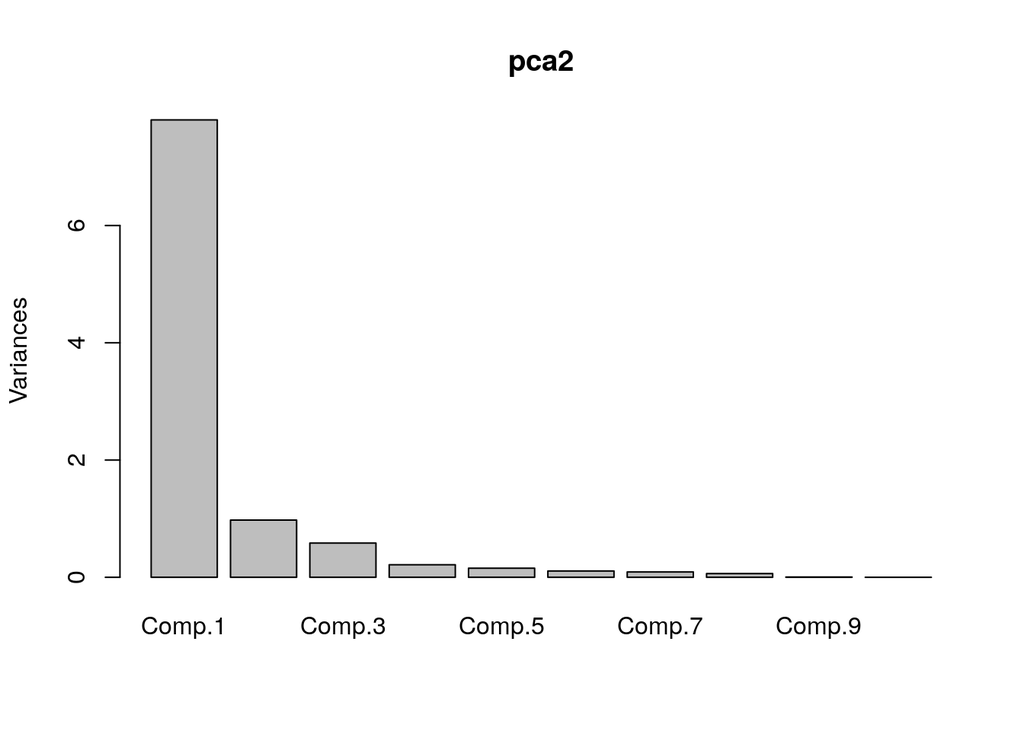

```r
screeplot(pca2)
```

```r
summary(pca2)
```

```
## Importance of components:
##                           Comp.1    Comp.2     Comp.3     Comp.4
## Standard deviation     2.7932931 0.9878319 0.76413947 0.46287316
## Proportion of Variance 0.7802486 0.0975812 0.05839091 0.02142516
## Cumulative Proportion  0.7802486 0.8778298 0.93622072 0.95764588
##                            Comp.5     Comp.6      Comp.7      Comp.8
## Standard deviation     0.39411718 0.32862243 0.302649525 0.252623930
## Proportion of Variance 0.01553284 0.01079927 0.009159673 0.006381885
## Cumulative Proportion  0.97317871 0.98397798 0.993137655 0.999519540
##                              Comp.9 Comp.10
## Standard deviation     0.0693151967       0
## Proportion of Variance 0.0004804596       0
## Cumulative Proportion  1.0000000000       1
```

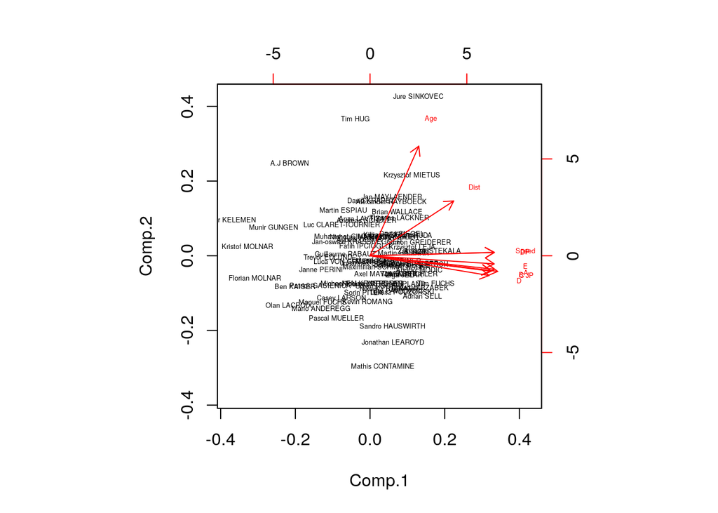

```r
biplot(pca2, cex =0.4)
```

## f)

```r
pca2sc <- as.data.frame(pca2["scores"])
summary(pca2)
```

```
## Importance of components:
##                           Comp.1    Comp.2     Comp.3     Comp.4
## Standard deviation     2.7932931 0.9878319 0.76413947 0.46287316
## Proportion of Variance 0.7802486 0.0975812 0.05839091 0.02142516
## Cumulative Proportion  0.7802486 0.8778298 0.93622072 0.95764588
##                            Comp.5     Comp.6      Comp.7      Comp.8
## Standard deviation     0.39411718 0.32862243 0.302649525 0.252623930
## Proportion of Variance 0.01553284 0.01079927 0.009159673 0.006381885
## Cumulative Proportion  0.97317871 0.98397798 0.993137655 0.999519540
##                              Comp.9 Comp.10
## Standard deviation     0.0693151967       0
## Proportion of Variance 0.0004804596       0
## Cumulative Proportion  1.0000000000       1
```

```r
apply(pca2sc, 2, sd)
```

```
##  scores.Comp.1  scores.Comp.2  scores.Comp.3  scores.Comp.4  scores.Comp.5
##   2.813462e+00   9.949644e-01   7.696568e-01   4.662153e-01   3.969628e-01
##  scores.Comp.6  scores.Comp.7  scores.Comp.8  scores.Comp.9 scores.Comp.10
##   3.309952e-01   3.048347e-01   2.544480e-01   6.981567e-02   1.822184e-15
```

```r
apply(pca2sc, 2, sd)*sqrt(69/70) - pca2$sdev
```

```
##  scores.Comp.1  scores.Comp.2  scores.Comp.3  scores.Comp.4  scores.Comp.5
##   4.440892e-16   4.440892e-16   4.440892e-16   6.661338e-16   5.551115e-16
##  scores.Comp.6  scores.Comp.7  scores.Comp.8  scores.Comp.9 scores.Comp.10
##   4.440892e-16  -1.110223e-16   8.881784e-16   1.387779e-16   1.809121e-15
```

We obtain the same result scaled by $\sqrt{{\frac{69}{70}}}$

## g)

```r
cor(as.matrix(pca2sc))
```

```
##                scores.Comp.1 scores.Comp.2 scores.Comp.3 scores.Comp.4
## scores.Comp.1   1.000000e+00 -1.478746e-15  7.631560e-16 -6.884276e-16
## scores.Comp.2  -1.478746e-15  1.000000e+00 -2.450483e-17 -1.254767e-16
## scores.Comp.3   7.631560e-16 -2.450483e-17  1.000000e+00  7.382897e-16
## scores.Comp.4  -6.884276e-16 -1.254767e-16  7.382897e-16  1.000000e+00
## scores.Comp.5   3.264174e-16  5.235518e-17 -2.609467e-16 -1.165474e-15
## scores.Comp.6   7.356404e-16 -3.078445e-16  4.329143e-16 -2.130872e-16
## scores.Comp.7   9.895981e-16  1.254304e-15 -2.210192e-15 -2.977008e-16
## scores.Comp.8   1.359887e-15  2.518124e-16 -9.359455e-16  4.744467e-16
## scores.Comp.9   1.371236e-15  2.500490e-16 -2.163450e-15 -5.693882e-15
## scores.Comp.10 -1.576339e-01  3.921248e-02 -5.819376e-02  5.320748e-02
##                scores.Comp.5 scores.Comp.6 scores.Comp.7 scores.Comp.8
## scores.Comp.1   3.264174e-16  7.356404e-16  9.895981e-16  1.359887e-15
## scores.Comp.2   5.235518e-17 -3.078445e-16  1.254304e-15  2.518124e-16
## scores.Comp.3  -2.609467e-16  4.329143e-16 -2.210192e-15 -9.359455e-16
## scores.Comp.4  -1.165474e-15 -2.130872e-16 -2.977008e-16  4.744467e-16
## scores.Comp.5   1.000000e+00 -1.400081e-15 -1.891653e-15 -2.137908e-15
## scores.Comp.6  -1.400081e-15  1.000000e+00 -4.821100e-16 -5.816711e-16
## scores.Comp.7  -1.891653e-15 -4.821100e-16  1.000000e+00 -1.614070e-16
## scores.Comp.8  -2.137908e-15 -5.816711e-16 -1.614070e-16  1.000000e+00
## scores.Comp.9  -1.139380e-14 -4.057808e-15 -5.182463e-15  9.344912e-15
## scores.Comp.10 -2.355962e-02 -2.329577e-02 -3.683558e-02 -5.039878e-01
##                scores.Comp.9 scores.Comp.10
## scores.Comp.1   1.371236e-15    -0.15763389
## scores.Comp.2   2.500490e-16     0.03921248
## scores.Comp.3  -2.163450e-15    -0.05819376
## scores.Comp.4  -5.693882e-15     0.05320748
## scores.Comp.5  -1.139380e-14    -0.02355962
## scores.Comp.6  -4.057808e-15    -0.02329577
## scores.Comp.7  -5.182463e-15    -0.03683558
## scores.Comp.8   9.344912e-15    -0.50398780
## scores.Comp.9   1.000000e+00     0.84126673
## scores.Comp.10  8.412667e-01     1.00000000
```

Nah

## h)

```r
scale(as.matrix(dd2))
```

[output not shown]

[output cut: 168 more lines]

```
## Ben KAISER             -1.29964862 -1.48460885
## Munir GUNGEN           -2.54588702 -2.25554816
## Kristof MOLNAR         -2.54588702 -2.71811175
## Florian MOLNAR         -1.71506142 -2.56392389
## Peter KELEMEN          -3.37671262 -3.18067534
## attr(,"scaled:center")
##      Age    Speed     Dist       DP        A        B        C        D
## 22.40000 99.37857 92.91857 49.88143 16.50000 16.27857 16.26429 16.52143
##        E       JP
## 16.56429 49.31429
## attr(,"scaled:scale")
##        Age      Speed       Dist         DP          A          B
##  2.8610325 10.7970191  0.5611306 19.4346344  1.1452485  1.2295743
##          C          D          E         JP
##  1.2090283  0.8945719  1.2036220  3.2427974
```

```r
eigen(t(scale(as.matrix(dd2)))%*%scale(as.matrix(dd2)))
```

```
## eigen() decomposition
## $values
##  [1]  5.383715e+02  6.733103e+01  4.028973e+01  1.478336e+01  1.071766e+01
##  [6]  7.451496e+00  6.320175e+00  4.403501e+00  3.315172e-01 -7.993606e-15
##
## $vectors
##             [,1]        [,2]        [,3]         [,4]        [,5]
##  [1,] -0.1348410  0.85613306  0.49379977 -0.014727931 -0.02244862
##  [2,] -0.3433486  0.02592275 -0.10924715  0.543556844 -0.17109370
##  [3,] -0.2311956  0.42785186 -0.80842710 -0.312575482  0.09869006
##  [4,] -0.3433486  0.02592275 -0.10924715  0.543556844 -0.17109370
##  [5,] -0.3444740 -0.10605208  0.02895513 -0.002538187 -0.04418761
##  [6,] -0.3339174 -0.11777332  0.21199864 -0.333781359  0.22770441
##  [7,] -0.3347305 -0.12097347  0.10535315  0.046912642  0.68249122
##  [8,] -0.3289995 -0.15440926  0.11256552 -0.422349774 -0.63634383
##  [9,] -0.3431225 -0.06355319  0.02946236 -0.053607446 -0.02732870
## [10,] -0.3527161 -0.12248095  0.09119974 -0.127676336  0.07703112
##              [,6]          [,7]         [,8]          [,9]         [,10]
##  [1,]  0.02737181  5.822288e-02  0.007581043 -0.0099219701  4.583580e-16
##  [2,] -0.19351052 -8.430337e-02 -0.012733633  0.0078871885 -7.071068e-01
##  [3,] -0.04599909  8.124728e-03  0.017644822  0.0007574035  2.220446e-16
##  [4,] -0.19351052 -8.430337e-02 -0.012733633  0.0078871885  7.071068e-01
##  [5,]  0.47753485  2.278398e-01  0.714958166  0.2760028026 -8.715251e-15
##  [6,] -0.41112125 -6.338690e-01  0.217813590  0.2194824381 -7.299716e-15
##  [7,] -0.15629979  5.213165e-01 -0.266384708  0.1645152077 -6.522560e-15
##  [8,] -0.26917476  3.756318e-01 -0.211688762  0.1164771566 -4.662937e-15
##  [9,]  0.64853108 -3.402337e-01 -0.560869601  0.1510397549 -5.800915e-15
## [10,]  0.08777683 -1.317203e-05  0.101741364 -0.9011000436  3.277933e-14
```